# Added Variable Plot

An added variable plot checks to see if a new variable has any information to add to the current multiple regression model.

The plot is made by taking the residuals from the current multiple regression model ($y$-axis) and plotting them against the new explanatory variable ($x$-axis).

- If there is a trend in the added variable plot, then the new explanatory variable contains extra information that is not already contained in the current multiple regression. The new variable should be included in the model.
- If there is no trend in the added variable plot, then the information provided by the new explanatory variable is already contained in the current multiple regression model. The new variable should continue to be left out of the model.

To make this graph plot the residuals with your new variable.

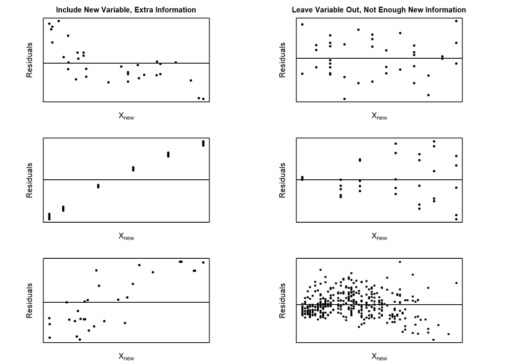

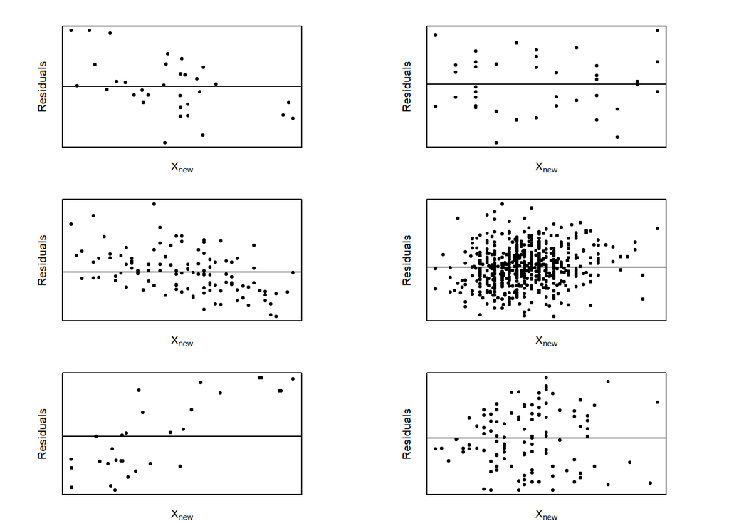

```r
plot(myData.lm$residuals ~ X2, data = myData.lm)
```